# Risk Factor Analysis

## Outcome Variable

**Outcome Variable:** wast_rec90d

## Predictor Variables

**Intervention Variable:** hdlvry

**Adjustment Set:**

- arm
- sex
- W_mage
- meducyrs
- feducyrs
- hhwealth_quart
- W_nrooms
- brthmon
- W_parity
- impsan
- delta_W_mage
- delta_meducyrs
- delta_feducyrs
- delta_hhwealth_quart
- delta_W_nrooms
- delta_brthmon
- delta_W_parity
- delta_impsan

## Stratifying Variables

The analysis was stratified on these variable(s):

- agecat
- studyid
- country

## Data Summary

| agecat | studyid | country | hdlvry | wast_rec90d | n_cell | n |
| --- | --- | --- | --- | --- | --- | --- |
| 0-24 months | ki1000108-CMC-V-BCS-2002 | INDIA | 0 | 0 | 115 | 322 |
| 0-24 months | ki1000108-CMC-V-BCS-2002 | INDIA | 0 | 1 | 200 | 322 |
| 0-24 months | ki1000108-CMC-V-BCS-2002 | INDIA | 1 | 0 | 4 | 322 |
| 0-24 months | ki1000108-CMC-V-BCS-2002 | INDIA | 1 | 1 | 3 | 322 |
| 0-24 months | ki1000108-IRC | INDIA | 0 | 0 | 159 | 395 |
| 0-24 months | ki1000108-IRC | INDIA | 0 | 1 | 227 | 395 |
| 0-24 months | ki1000108-IRC | INDIA | 1 | 0 | 3 | 395 |
| 0-24 months | ki1000108-IRC | INDIA | 1 | 1 | 6 | 395 |
| 0-24 months | ki1000109-EE | PAKISTAN | 0 | 0 | 97 | 255 |
| 0-24 months | ki1000109-EE | PAKISTAN | 0 | 1 | 72 | 255 |
| 0-24 months | ki1000109-EE | PAKISTAN | 1 | 0 | 51 | 255 |
| 0-24 months | ki1000109-EE | PAKISTAN | 1 | 1 | 35 | 255 |
| 0-24 months | ki1000304b-SAS-CompFeed | INDIA | 0 | 0 | 34 | 675 |
| 0-24 months | ki1000304b-SAS-CompFeed | INDIA | 0 | 1 | 30 | 675 |
| 0-24 months | ki1000304b-SAS-CompFeed | INDIA | 1 | 0 | 386 | 675 |
| 0-24 months | ki1000304b-SAS-CompFeed | INDIA | 1 | 1 | 225 | 675 |
| 0-24 months | ki1000304b-SAS-FoodSuppl | INDIA | 0 | 0 | 40 | 234 |
| 0-24 months | ki1000304b-SAS-FoodSuppl | INDIA | 0 | 1 | 0 | 234 |
| 0-24 months | ki1000304b-SAS-FoodSuppl | INDIA | 1 | 0 | 181 | 234 |
| 0-24 months | ki1000304b-SAS-FoodSuppl | INDIA | 1 | 1 | 13 | 234 |
| 0-24 months | ki1017093b-PROVIDE | BANGLADESH | 0 | 0 | 94 | 307 |
| 0-24 months | ki1017093b-PROVIDE | BANGLADESH | 0 | 1 | 132 | 307 |
| 0-24 months | ki1017093b-PROVIDE | BANGLADESH | 1 | 0 | 34 | 307 |
| 0-24 months | ki1017093b-PROVIDE | BANGLADESH | 1 | 1 | 47 | 307 |
| 0-24 months | ki1017093c-NIH-Crypto | BANGLADESH | 0 | 0 | 79 | 311 |
| 0-24 months | ki1017093c-NIH-Crypto | BANGLADESH | 0 | 1 | 139 | 311 |
| 0-24 months | ki1017093c-NIH-Crypto | BANGLADESH | 1 | 0 | 38 | 311 |
| 0-24 months | ki1017093c-NIH-Crypto | BANGLADESH | 1 | 1 | 55 | 311 |
| 0-24 months | ki1066203-TanzaniaChild2 | TANZANIA, UNITED REPUBLIC OF | 0 | 0 | 250 | 682 |
| 0-24 months | ki1066203-TanzaniaChild2 | TANZANIA, UNITED REPUBLIC OF | 0 | 1 | 423 | 682 |

[output cut: 114 more lines]

The following strata were considered:

- agecat: 0-24 months, studyid: ki1000108-CMC-V-BCS-2002, country: INDIA
- agecat: 0-24 months, studyid: ki1000108-IRC, country: INDIA
- agecat: 0-24 months, studyid: ki1000109-EE, country: PAKISTAN
- agecat: 0-24 months, studyid: ki1000304b-SAS-CompFeed, country: INDIA
- agecat: 0-24 months, studyid: ki1000304b-SAS-FoodSuppl, country: INDIA
- agecat: 0-24 months, studyid: ki1017093b-PROVIDE, country: BANGLADESH
- agecat: 0-24 months, studyid: ki1017093c-NIH-Crypto, country: BANGLADESH
- agecat: 0-24 months, studyid: ki1066203-TanzaniaChild2, country: TANZANIA, UNITED REPUBLIC OF
- agecat: 0-24 months, studyid: ki1113344-GMS-Nepal, country: NEPAL
- agecat: 0-24 months, studyid: ki1135781-COHORTS, country: INDIA
- agecat: 0-24 months, studyid: kiGH5241-JiVitA-3, country: BANGLADESH
- agecat: 0-24 months, studyid: kiGH5241-JiVitA-4, country: BANGLADESH
- agecat: 0-6 months, studyid: ki1000108-CMC-V-BCS-2002, country: INDIA
- agecat: 0-6 months, studyid: ki1000108-IRC, country: INDIA
- agecat: 0-6 months, studyid: ki1000109-EE, country: PAKISTAN
- agecat: 0-6 months, studyid: ki1000304b-SAS-CompFeed, country: INDIA
- agecat: 0-6 months, studyid: ki1000304b-SAS-FoodSuppl, country: INDIA
- agecat: 0-6 months, studyid: ki1017093b-PROVIDE, country: BANGLADESH
- agecat: 0-6 months, studyid: ki1017093c-NIH-Crypto, country: BANGLADESH
- agecat: 0-6 months, studyid: ki1066203-TanzaniaChild2, country: TANZANIA, UNITED REPUBLIC OF
- agecat: 0-6 months, studyid: ki1113344-GMS-Nepal, country: NEPAL
- agecat: 0-6 months, studyid: ki1135781-COHORTS, country: INDIA
- agecat: 0-6 months, studyid: kiGH5241-JiVitA-3, country: BANGLADESH
- agecat: 0-6 months, studyid: kiGH5241-JiVitA-4, country: BANGLADESH
- agecat: 6-24 months, studyid: ki1000108-CMC-V-BCS-2002, country: INDIA
- agecat: 6-24 months, studyid: ki1000108-IRC, country: INDIA
- agecat: 6-24 months, studyid: ki1000109-EE, country: PAKISTAN
- agecat: 6-24 months, studyid: ki1000304b-SAS-CompFeed, country: INDIA
- agecat: 6-24 months, studyid: ki1000304b-SAS-FoodSuppl, country: INDIA
- agecat: 6-24 months, studyid: ki1017093b-PROVIDE, country: BANGLADESH
- agecat: 6-24 months, studyid: ki1017093c-NIH-Crypto, country: BANGLADESH
- agecat: 6-24 months, studyid: ki1066203-TanzaniaChild2, country: TANZANIA, UNITED REPUBLIC OF
- agecat: 6-24 months, studyid: ki1113344-GMS-Nepal, country: NEPAL
- agecat: 6-24 months, studyid: ki1135781-COHORTS, country: INDIA
- agecat: 6-24 months, studyid: kiGH5241-JiVitA-3, country: BANGLADESH
- agecat: 6-24 months, studyid: kiGH5241-JiVitA-4, country: BANGLADESH

### Dropped Strata

- agecat: 0-24 months, studyid: ki1000108-CMC-V-BCS-2002, country: INDIA
- agecat: 0-24 months, studyid: ki1000108-IRC, country: INDIA
- agecat: 0-24 months, studyid: ki1000304b-SAS-FoodSuppl, country: INDIA
- agecat: 0-24 months, studyid: ki1066203-TanzaniaChild2, country: TANZANIA, UNITED REPUBLIC OF
- agecat: 0-6 months, studyid: ki1000108-CMC-V-BCS-2002, country: INDIA
- agecat: 0-6 months, studyid: ki1000108-IRC, country: INDIA
- agecat: 0-6 months, studyid: ki1000304b-SAS-FoodSuppl, country: INDIA
- agecat: 0-6 months, studyid: ki1066203-TanzaniaChild2, country: TANZANIA, UNITED REPUBLIC OF
- agecat: 0-6 months, studyid: kiGH5241-JiVitA-3, country: BANGLADESH
- agecat: 6-24 months, studyid: ki1000108-CMC-V-BCS-2002, country: INDIA
- agecat: 6-24 months, studyid: ki1000108-IRC, country: INDIA
- agecat: 6-24 months, studyid: ki1000304b-SAS-FoodSuppl, country: INDIA
- agecat: 6-24 months, studyid: ki1017093c-NIH-Crypto, country: BANGLADESH
- agecat: 6-24 months, studyid: ki1066203-TanzaniaChild2, country: TANZANIA, UNITED REPUBLIC OF
- agecat: 6-24 months, studyid: ki1135781-COHORTS, country: INDIA
- agecat: 6-24 months, studyid: kiGH5241-JiVitA-3, country: BANGLADESH

## Methods Detail

We’re interested in the causal parameters $E[Y_a]$ for all values of $a \in \mathcal{A}$. These parameters represent the mean outcome if, possibly contrary to fact, we intervened to set all units to have $A=a$. Under the randomization and positivity assumptions, these are identified by the statistical parameters $\psi_a=E_W[E_{Y|A,W}(Y|A=a,W)]$. In addition, we’re interested in the mean of $Y$, $E[Y]$ under no intervention (the observed mean). We will estimate these parameters by using SuperLearner to fit the relevant likelihood factors – $E_{Y|A,W}(Y|A=a,W)$ and $p(A=a|W)$, and then updating our likelihood fit using a joint TMLE.

For unadjusted analyses ($W=\{\}$), initial likelihoods were estimated using Lrnr_glm to estimate the simple $E(Y|A)$ and Lrnr_mean to estimate $p(A)$. For adjusted analyses, a small library containing Lrnr_glmnet, Lrnr_xgboost, and Lrnr_mean was used.

Having estimated these parameters, we will then use the delta method to estimate relative risks and attributable risks relative to a prespecified baseline level of $A$.

# Results Detail

## Results Plots

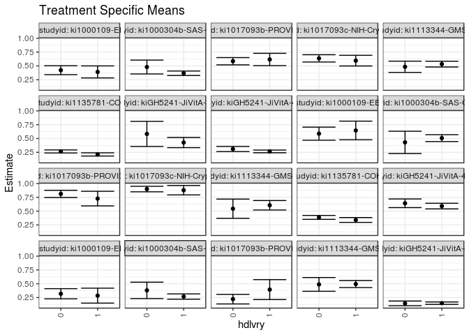

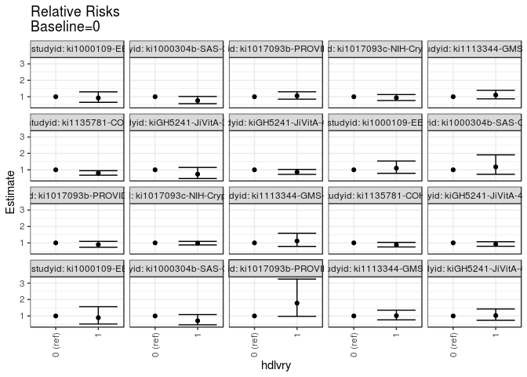

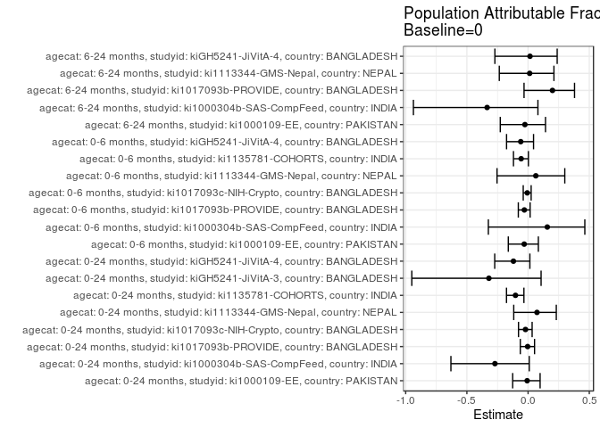

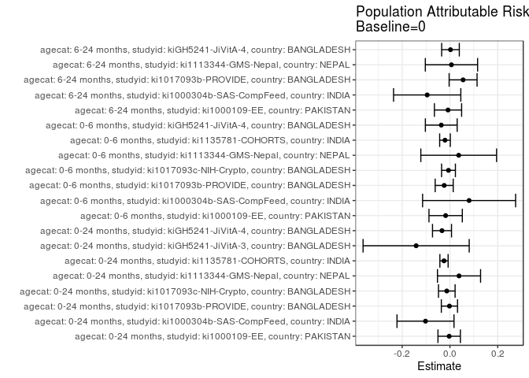

## Results Table

### Parameter: TSM

| agecat | studyid | country | intervention_level | baseline_level | estimate | ci_lower | ci_upper |
| --- | --- | --- | --- | --- | --- | --- | --- |
| 0-24 months | ki1000109-EE | PAKISTAN | 0 | NA | 0.4228077 | 0.3419683 | 0.5036470 |
| 0-24 months | ki1000109-EE | PAKISTAN | 1 | NA | 0.3913017 | 0.2825427 | 0.5000608 |
| 0-24 months | ki1000304b-SAS-CompFeed | INDIA | 0 | NA | 0.4800737 | 0.3544728 | 0.6056747 |
| 0-24 months | ki1000304b-SAS-CompFeed | INDIA | 1 | NA | 0.3671642 | 0.3270643 | 0.4072641 |
| 0-24 months | ki1017093b-PROVIDE | BANGLADESH | 0 | NA | 0.5852012 | 0.5192020 | 0.6512004 |
| 0-24 months | ki1017093b-PROVIDE | BANGLADESH | 1 | NA | 0.6167443 | 0.5053410 | 0.7281476 |
| 0-24 months | ki1017093c-NIH-Crypto | BANGLADESH | 0 | NA | 0.6369545 | 0.5709787 | 0.7029303 |
| 0-24 months | ki1017093c-NIH-Crypto | BANGLADESH | 1 | NA | 0.5955356 | 0.4989468 | 0.6921244 |
| 0-24 months | ki1113344-GMS-Nepal | NEPAL | 0 | NA | 0.4843737 | 0.3824362 | 0.5863111 |
| 0-24 months | ki1113344-GMS-Nepal | NEPAL | 1 | NA | 0.5329867 | 0.4804720 | 0.5855014 |
| 0-24 months | ki1135781-COHORTS | INDIA | 0 | NA | 0.2662094 | 0.2387754 | 0.2936435 |
| 0-24 months | ki1135781-COHORTS | INDIA | 1 | NA | 0.2121797 | 0.1832083 | 0.2411510 |
| 0-24 months | kiGH5241-JiVitA-3 | BANGLADESH | 0 | NA | 0.5833333 | 0.3560459 | 0.8106207 |
| 0-24 months | kiGH5241-JiVitA-3 | BANGLADESH | 1 | NA | 0.4273504 | 0.3351375 | 0.5195633 |
| 0-24 months | kiGH5241-JiVitA-4 | BANGLADESH | 0 | NA | 0.3103167 | 0.2637581 | 0.3568753 |
| 0-24 months | kiGH5241-JiVitA-4 | BANGLADESH | 1 | NA | 0.2667053 | 0.2423902 | 0.2910204 |
| 0-6 months | ki1000109-EE | PAKISTAN | 0 | NA | 0.5881066 | 0.4696251 | 0.7065881 |
| 0-6 months | ki1000109-EE | PAKISTAN | 1 | NA | 0.6458257 | 0.4769594 | 0.8146920 |
| 0-6 months | ki1000304b-SAS-CompFeed | INDIA | 0 | NA | 0.4305643 | 0.2290278 | 0.6321007 |
| 0-6 months | ki1000304b-SAS-CompFeed | INDIA | 1 | NA | 0.5073160 | 0.4448709 | 0.5697612 |
| 0-6 months | ki1017093b-PROVIDE | BANGLADESH | 0 | NA | 0.8120694 | 0.7468001 | 0.8773387 |
| 0-6 months | ki1017093b-PROVIDE | BANGLADESH | 1 | NA | 0.7272838 | 0.5951386 | 0.8594291 |
| 0-6 months | ki1017093c-NIH-Crypto | BANGLADESH | 0 | NA | 0.9000000 | 0.8497106 | 0.9502894 |
| 0-6 months | ki1017093c-NIH-Crypto | BANGLADESH | 1 | NA | 0.8793103 | 0.7944001 | 0.9642206 |
| 0-6 months | ki1113344-GMS-Nepal | NEPAL | 0 | NA | 0.5441640 | 0.3701817 | 0.7181464 |
| 0-6 months | ki1113344-GMS-Nepal | NEPAL | 1 | NA | 0.6063140 | 0.5207284 | 0.6918996 |
| 0-6 months | ki1135781-COHORTS | INDIA | 0 | NA | 0.3865599 | 0.3511893 | 0.4219305 |
| 0-6 months | ki1135781-COHORTS | INDIA | 1 | NA | 0.3400967 | 0.2965176 | 0.3836757 |
| 0-6 months | kiGH5241-JiVitA-4 | BANGLADESH | 0 | NA | 0.6422450 | 0.5639509 | 0.7205391 |
| 0-6 months | kiGH5241-JiVitA-4 | BANGLADESH | 1 | NA | 0.5915025 | 0.5404494 | 0.6425556 |
| 6-24 months | ki1000109-EE | PAKISTAN | 0 | NA | 0.3188734 | 0.2271351 | 0.4106116 |
| 6-24 months | ki1000109-EE | PAKISTAN | 1 | NA | 0.2849323 | 0.1497277 | 0.4201369 |
| 6-24 months | ki1000304b-SAS-CompFeed | INDIA | 0 | NA | 0.3798725 | 0.2315421 | 0.5282028 |
| 6-24 months | ki1000304b-SAS-CompFeed | INDIA | 1 | NA | 0.2683686 | 0.2206495 | 0.3160878 |
| 6-24 months | ki1017093b-PROVIDE | BANGLADESH | 0 | NA | 0.2213297 | 0.1345608 | 0.3080986 |
| 6-24 months | ki1017093b-PROVIDE | BANGLADESH | 1 | NA | 0.3942606 | 0.2140127 | 0.5745086 |
| 6-24 months | ki1113344-GMS-Nepal | NEPAL | 0 | NA | 0.4878336 | 0.3635758 | 0.6120913 |
| 6-24 months | ki1113344-GMS-Nepal | NEPAL | 1 | NA | 0.4945528 | 0.4306375 | 0.5584682 |
| 6-24 months | kiGH5241-JiVitA-4 | BANGLADESH | 0 | NA | 0.1444925 | 0.1020935 | 0.1868915 |
| 6-24 months | kiGH5241-JiVitA-4 | BANGLADESH | 1 | NA | 0.1482090 | 0.1263582 | 0.1700597 |

### Parameter: E(Y)

| agecat | studyid | country | intervention_level | baseline_level | estimate | ci_lower | ci_upper |
| --- | --- | --- | --- | --- | --- | --- | --- |
| 0-24 months | ki1000109-EE | PAKISTAN | NA | NA | 0.4196078 | 0.3541827 | 0.4850330 |
| 0-24 months | ki1000304b-SAS-CompFeed | INDIA | NA | NA | 0.3777778 | 0.3394240 | 0.4161316 |
| 0-24 months | ki1017093b-PROVIDE | BANGLADESH | NA | NA | 0.5830619 | 0.5262762 | 0.6398476 |
| 0-24 months | ki1017093c-NIH-Crypto | BANGLADESH | NA | NA | 0.6237942 | 0.5698223 | 0.6777662 |
| 0-24 months | ki1113344-GMS-Nepal | NEPAL | NA | NA | 0.5224172 | 0.4758292 | 0.5690051 |
| 0-24 months | ki1135781-COHORTS | INDIA | NA | NA | 0.2413610 | 0.2219406 | 0.2607813 |
| 0-24 months | kiGH5241-JiVitA-3 | BANGLADESH | NA | NA | 0.4418605 | 0.3551361 | 0.5285849 |
| 0-24 months | kiGH5241-JiVitA-4 | BANGLADESH | NA | NA | 0.2771220 | 0.2556194 | 0.2986246 |
| 0-6 months | ki1000109-EE | PAKISTAN | NA | NA | 0.5700935 | 0.4742263 | 0.6659606 |
| 0-6 months | ki1000304b-SAS-CompFeed | INDIA | NA | NA | 0.5107914 | 0.4514901 | 0.5700927 |
| 0-6 months | ki1017093b-PROVIDE | BANGLADESH | NA | NA | 0.7880435 | 0.7295878 | 0.8464992 |
| 0-6 months | ki1017093c-NIH-Crypto | BANGLADESH | NA | NA | 0.8939394 | 0.8505280 | 0.9373508 |
| 0-6 months | ki1113344-GMS-Nepal | NEPAL | NA | NA | 0.5808383 | 0.5055058 | 0.6561709 |
| 0-6 months | ki1135781-COHORTS | INDIA | NA | NA | 0.3658340 | 0.3390250 | 0.3926430 |
| 0-6 months | kiGH5241-JiVitA-4 | BANGLADESH | NA | NA | 0.6059406 | 0.5632798 | 0.6486014 |
| 6-24 months | ki1000109-EE | PAKISTAN | NA | NA | 0.3108108 | 0.2352987 | 0.3863229 |
| 6-24 months | ki1000304b-SAS-CompFeed | INDIA | NA | NA | 0.2846348 | 0.2390527 | 0.3302168 |
| 6-24 months | ki1017093b-PROVIDE | BANGLADESH | NA | NA | 0.2764228 | 0.1950773 | 0.3577682 |
| 6-24 months | ki1113344-GMS-Nepal | NEPAL | NA | NA | 0.4942197 | 0.4375393 | 0.5509000 |
| 6-24 months | kiGH5241-JiVitA-4 | BANGLADESH | NA | NA | 0.1467818 | 0.1275683 | 0.1659953 |

### Parameter: RR

| agecat | studyid | country | intervention_level | baseline_level | estimate | ci_lower | ci_upper |
| --- | --- | --- | --- | --- | --- | --- | --- |
| 0-24 months | ki1000109-EE | PAKISTAN | 0 | 0 | 1.0000000 | 1.0000000 | 1.0000000 |
| 0-24 months | ki1000109-EE | PAKISTAN | 1 | 0 | 0.9254840 | 0.6600604 | 1.2976399 |
| 0-24 months | ki1000304b-SAS-CompFeed | INDIA | 0 | 0 | 1.0000000 | 1.0000000 | 1.0000000 |
| 0-24 months | ki1000304b-SAS-CompFeed | INDIA | 1 | 0 | 0.7648079 | 0.5763805 | 1.0148350 |
| 0-24 months | ki1017093b-PROVIDE | BANGLADESH | 0 | 0 | 1.0000000 | 1.0000000 | 1.0000000 |
| 0-24 months | ki1017093b-PROVIDE | BANGLADESH | 1 | 0 | 1.0539012 | 0.8527867 | 1.3024450 |
| 0-24 months | ki1017093c-NIH-Crypto | BANGLADESH | 0 | 0 | 1.0000000 | 1.0000000 | 1.0000000 |
| 0-24 months | ki1017093c-NIH-Crypto | BANGLADESH | 1 | 0 | 0.9349735 | 0.7707287 | 1.1342194 |
| 0-24 months | ki1113344-GMS-Nepal | NEPAL | 0 | 0 | 1.0000000 | 1.0000000 | 1.0000000 |
| 0-24 months | ki1113344-GMS-Nepal | NEPAL | 1 | 0 | 1.1003627 | 0.8719810 | 1.3885602 |
| 0-24 months | ki1135781-COHORTS | INDIA | 0 | 0 | 1.0000000 | 1.0000000 | 1.0000000 |
| 0-24 months | ki1135781-COHORTS | INDIA | 1 | 0 | 0.7970403 | 0.6715512 | 0.9459789 |
| 0-24 months | kiGH5241-JiVitA-3 | BANGLADESH | 0 | 0 | 1.0000000 | 1.0000000 | 1.0000000 |
| 0-24 months | kiGH5241-JiVitA-3 | BANGLADESH | 1 | 0 | 0.7326007 | 0.4692527 | 1.1437415 |
| 0-24 months | kiGH5241-JiVitA-4 | BANGLADESH | 0 | 0 | 1.0000000 | 1.0000000 | 1.0000000 |
| 0-24 months | kiGH5241-JiVitA-4 | BANGLADESH | 1 | 0 | 0.8594616 | 0.7210181 | 1.0244878 |
| 0-6 months | ki1000109-EE | PAKISTAN | 0 | 0 | 1.0000000 | 1.0000000 | 1.0000000 |
| 0-6 months | ki1000109-EE | PAKISTAN | 1 | 0 | 1.0981439 | 0.7857499 | 1.5347378 |
| 0-6 months | ki1000304b-SAS-CompFeed | INDIA | 0 | 0 | 1.0000000 | 1.0000000 | 1.0000000 |
| 0-6 months | ki1000304b-SAS-CompFeed | INDIA | 1 | 0 | 1.1782586 | 0.7256920 | 1.9130612 |
| 0-6 months | ki1017093b-PROVIDE | BANGLADESH | 0 | 0 | 1.0000000 | 1.0000000 | 1.0000000 |
| 0-6 months | ki1017093b-PROVIDE | BANGLADESH | 1 | 0 | 0.8955931 | 0.7336167 | 1.0933326 |
| 0-6 months | ki1017093c-NIH-Crypto | BANGLADESH | 0 | 0 | 1.0000000 | 1.0000000 | 1.0000000 |
| 0-6 months | ki1017093c-NIH-Crypto | BANGLADESH | 1 | 0 | 0.9770115 | 0.8738707 | 1.0923258 |
| 0-6 months | ki1113344-GMS-Nepal | NEPAL | 0 | 0 | 1.0000000 | 1.0000000 | 1.0000000 |
| 0-6 months | ki1113344-GMS-Nepal | NEPAL | 1 | 0 | 1.1142118 | 0.7844403 | 1.5826162 |
| 0-6 months | ki1135781-COHORTS | INDIA | 0 | 0 | 1.0000000 | 1.0000000 | 1.0000000 |
| 0-6 months | ki1135781-COHORTS | INDIA | 1 | 0 | 0.8798033 | 0.7515700 | 1.0299159 |
| 0-6 months | kiGH5241-JiVitA-4 | BANGLADESH | 0 | 0 | 1.0000000 | 1.0000000 | 1.0000000 |
| 0-6 months | kiGH5241-JiVitA-4 | BANGLADESH | 1 | 0 | 0.9209919 | 0.7930428 | 1.0695843 |
| 6-24 months | ki1000109-EE | PAKISTAN | 0 | 0 | 1.0000000 | 1.0000000 | 1.0000000 |
| 6-24 months | ki1000109-EE | PAKISTAN | 1 | 0 | 0.8935595 | 0.5104483 | 1.5642104 |
| 6-24 months | ki1000304b-SAS-CompFeed | INDIA | 0 | 0 | 1.0000000 | 1.0000000 | 1.0000000 |
| 6-24 months | ki1000304b-SAS-CompFeed | INDIA | 1 | 0 | 0.7064704 | 0.4598670 | 1.0853147 |
| 6-24 months | ki1017093b-PROVIDE | BANGLADESH | 0 | 0 | 1.0000000 | 1.0000000 | 1.0000000 |
| 6-24 months | ki1017093b-PROVIDE | BANGLADESH | 1 | 0 | 1.7813275 | 0.9771175 | 3.2474373 |
| 6-24 months | ki1113344-GMS-Nepal | NEPAL | 0 | 0 | 1.0000000 | 1.0000000 | 1.0000000 |
| 6-24 months | ki1113344-GMS-Nepal | NEPAL | 1 | 0 | 1.0137737 | 0.7614574 | 1.3496974 |
| 6-24 months | kiGH5241-JiVitA-4 | BANGLADESH | 0 | 0 | 1.0000000 | 1.0000000 | 1.0000000 |
| 6-24 months | kiGH5241-JiVitA-4 | BANGLADESH | 1 | 0 | 1.0257208 | 0.7385478 | 1.4245567 |

### Parameter: PAR

| agecat | studyid | country | intervention_level | baseline_level | estimate | ci_lower | ci_upper |
| --- | --- | --- | --- | --- | --- | --- | --- |
| 0-24 months | ki1000109-EE | PAKISTAN | 0 | NA | -0.0031998 | -0.0501196 | 0.0437199 |
| 0-24 months | ki1000304b-SAS-CompFeed | INDIA | 0 | NA | -0.1022960 | -0.2215903 | 0.0169983 |
| 0-24 months | ki1017093b-PROVIDE | BANGLADESH | 0 | NA | -0.0021393 | -0.0360274 | 0.0317487 |
| 0-24 months | ki1017093c-NIH-Crypto | BANGLADESH | 0 | NA | -0.0131603 | -0.0479113 | 0.0215907 |
| 0-24 months | ki1113344-GMS-Nepal | NEPAL | 0 | NA | 0.0380435 | -0.0521365 | 0.1282235 |
| 0-24 months | ki1135781-COHORTS | INDIA | 0 | NA | -0.0248485 | -0.0421184 | -0.0075785 |
| 0-24 months | kiGH5241-JiVitA-3 | BANGLADESH | 0 | NA | -0.1414729 | -0.3635901 | 0.0806444 |
| 0-24 months | kiGH5241-JiVitA-4 | BANGLADESH | 0 | NA | -0.0331947 | -0.0729778 | 0.0065883 |
| 0-6 months | ki1000109-EE | PAKISTAN | 0 | NA | -0.0180131 | -0.0878013 | 0.0517751 |
| 0-6 months | ki1000304b-SAS-CompFeed | INDIA | 0 | NA | 0.0802271 | -0.1144733 | 0.2749276 |
| 0-6 months | ki1017093b-PROVIDE | BANGLADESH | 0 | NA | -0.0240260 | -0.0617560 | 0.0137041 |
| 0-6 months | ki1017093c-NIH-Crypto | BANGLADESH | 0 | NA | -0.0060606 | -0.0350005 | 0.0228793 |
| 0-6 months | ki1113344-GMS-Nepal | NEPAL | 0 | NA | 0.0366743 | -0.1218828 | 0.1952314 |
| 0-6 months | ki1135781-COHORTS | INDIA | 0 | NA | -0.0207259 | -0.0430006 | 0.0015488 |
| 0-6 months | kiGH5241-JiVitA-4 | BANGLADESH | 0 | NA | -0.0363044 | -0.1028629 | 0.0302540 |
| 6-24 months | ki1000109-EE | PAKISTAN | 0 | NA | -0.0080625 | -0.0650404 | 0.0489153 |
| 6-24 months | ki1000304b-SAS-CompFeed | INDIA | 0 | NA | -0.0952377 | -0.2360147 | 0.0455393 |
| 6-24 months | ki1017093b-PROVIDE | BANGLADESH | 0 | NA | 0.0550931 | -0.0033658 | 0.1135520 |
| 6-24 months | ki1113344-GMS-Nepal | NEPAL | 0 | NA | 0.0063861 | -0.1030013 | 0.1157735 |
| 6-24 months | kiGH5241-JiVitA-4 | BANGLADESH | 0 | NA | 0.0022893 | -0.0346272 | 0.0392058 |

### Parameter: PAF

| agecat | studyid | country | intervention_level | baseline_level | estimate | ci_lower | ci_upper |
| --- | --- | --- | --- | --- | --- | --- | --- |
| 0-24 months | ki1000109-EE | PAKISTAN | 0 | NA | -0.0076258 | -0.1258797 | 0.0982077 |
| 0-24 months | ki1000304b-SAS-CompFeed | INDIA | 0 | NA | -0.2707834 | -0.6305088 | 0.0095787 |
| 0-24 months | ki1017093b-PROVIDE | BANGLADESH | 0 | NA | -0.0036692 | -0.0635086 | 0.0528034 |
| 0-24 months | ki1017093c-NIH-Crypto | BANGLADESH | 0 | NA | -0.0210972 | -0.0782661 | 0.0330407 |
| 0-24 months | ki1113344-GMS-Nepal | NEPAL | 0 | NA | 0.0728221 | -0.1171425 | 0.2304841 |
| 0-24 months | ki1135781-COHORTS | INDIA | 0 | NA | -0.1029514 | -0.1763680 | -0.0341167 |
| 0-24 months | kiGH5241-JiVitA-3 | BANGLADESH | 0 | NA | -0.3201754 | -0.9499839 | 0.1062166 |
| 0-24 months | kiGH5241-JiVitA-4 | BANGLADESH | 0 | NA | -0.1197838 | -0.2725341 | 0.0146309 |
| 0-6 months | ki1000109-EE | PAKISTAN | 0 | NA | -0.0315968 | -0.1617116 | 0.0839448 |
| 0-6 months | ki1000304b-SAS-CompFeed | INDIA | 0 | NA | 0.1570643 | -0.3245783 | 0.4635723 |
| 0-6 months | ki1017093b-PROVIDE | BANGLADESH | 0 | NA | -0.0304881 | -0.0798624 | 0.0166286 |
| 0-6 months | ki1017093c-NIH-Crypto | BANGLADESH | 0 | NA | -0.0067797 | -0.0397071 | 0.0251050 |
| 0-6 months | ki1113344-GMS-Nepal | NEPAL | 0 | NA | 0.0631403 | -0.2536850 | 0.2998989 |
| 0-6 months | ki1135781-COHORTS | INDIA | 0 | NA | -0.0566539 | -0.1193464 | 0.0025274 |
| 0-6 months | kiGH5241-JiVitA-4 | BANGLADESH | 0 | NA | -0.0599142 | -0.1758395 | 0.0445821 |
| 6-24 months | ki1000109-EE | PAKISTAN | 0 | NA | -0.0259404 | -0.2272547 | 0.1423511 |
| 6-24 months | ki1000304b-SAS-CompFeed | INDIA | 0 | NA | -0.3345962 | -0.9368396 | 0.0803849 |
| 6-24 months | ki1017093b-PROVIDE | BANGLADESH | 0 | NA | 0.1993073 | -0.0330782 | 0.3794189 |
| 6-24 months | ki1113344-GMS-Nepal | NEPAL | 0 | NA | 0.0129216 | -0.2352358 | 0.2112245 |
| 6-24 months | kiGH5241-JiVitA-4 | BANGLADESH | 0 | NA | 0.0155966 | -0.2710912 | 0.2376235 |